# Trends in Redwine by Neil Amin

This dataset has 1599 records. It contains data on different red wines. The data set has variables for fixed acidity, volatile acidity, citric acid, residual sug ar, chlorides, free sulfur dioxide, total sulfur dioxide, density, ph, sulphates, and alcohol. The output is the quality of wine. My goal is to find trends between traits of wines that lead to a higher or lower quality wine.

Here we can see basic information about the dataset. We get statistics about the dataset and all 11 variables. X is not a variable but actually is the index of each record in the data. Quality is the output that we will be trying to find trends about.

# Univariate Plots Section

```
## 'data.frame':    1599 obs. of  13 variables:
##  $ X                   : int  1 2 3 4 5 6 7 8 9 10 ...
##  $ fixed.acidity       : num  7.4 7.8 7.8 11.2 7.4 7.4 7.9 7.3 7.8 7.5 ...
##  $ volatile.acidity    : num  0.7 0.88 0.76 0.28 0.7 0.66 0.6 0.65 0.58 0.5 ...
##  $ citric.acid         : num  0 0 0.04 0.56 0 0 0.06 0 0.02 0.36 ...
##  $ residual.sugar      : num  1.9 2.6 2.3 1.9 1.9 1.8 1.6 1.2 2 6.1 ...
##  $ chlorides           : num  0.076 0.098 0.092 0.075 0.076 0.075 0.069 0.065 0.073 0.071 ...
##  $ free.sulfur.dioxide : num  11 25 15 17 11 13 15 15 9 17 ...
##  $ total.sulfur.dioxide: num  34 67 54 60 34 40 59 21 18 102 ...
##  $ density             : num  0.998 0.997 0.997 0.998 0.998 ...
##  $ pH                  : num  3.51 3.2 3.26 3.16 3.51 3.51 3.3 3.39 3.36 3.35 ...
##  $ sulphates           : num  0.56 0.68 0.65 0.58 0.56 0.56 0.46 0.47 0.57 0.8 ...
##  $ alcohol             : num  9.4 9.8 9.8 9.8 9.4 9.4 9.4 10 9.5 10.5 ...
##  $ quality             : int  5 5 5 6 5 5 5 7 7 5 ...
```

```
##  [1] "X"                    "fixed.acidity"        "volatile.acidity"
##  [4] "citric.acid"          "residual.sugar"       "chlorides"
##  [7] "free.sulfur.dioxide"  "total.sulfur.dioxide" "density"
## [10] "pH"                   "sulphates"            "alcohol"
## [13] "quality"
```

```
##        X          fixed.acidity   volatile.acidity  citric.acid
##  Min.   :   1.0   Min.   : 4.60   Min.   :0.1200   Min.   :0.000
##  1st Qu.: 400.5   1st Qu.: 7.10   1st Qu.:0.3900   1st Qu.:0.090
##  Median : 800.0   Median : 7.90   Median :0.5200   Median :0.260
##  Mean   : 800.0   Mean   : 8.32   Mean   :0.5278   Mean   :0.271
##  3rd Qu.:1199.5   3rd Qu.: 9.20   3rd Qu.:0.6400   3rd Qu.:0.420
##  Max.   :1599.0   Max.   :15.90   Max.   :1.5800   Max.   :1.000
##  residual.sugar     chlorides       free.sulfur.dioxide
##  Min.   : 0.900   Min.   :0.01200   Min.   : 1.00
##  1st Qu.: 1.900   1st Qu.:0.07000   1st Qu.: 7.00
##  Median : 2.200   Median :0.07900   Median :14.00
##  Mean   : 2.539   Mean   :0.08747   Mean   :15.87
##  3rd Qu.: 2.600   3rd Qu.:0.09000   3rd Qu.:21.00
##  Max.   :15.500   Max.   :0.61100   Max.   :72.00
##  total.sulfur.dioxide    density             pH          sulphates
##  Min.   :  6.00       Min.   :0.9901   Min.   :2.740   Min.   :0.3300
##  1st Qu.: 22.00       1st Qu.:0.9956   1st Qu.:3.210   1st Qu.:0.5500
##  Median : 38.00       Median :0.9968   Median :3.310   Median :0.6200
##  Mean   : 46.47       Mean   :0.9967   Mean   :3.311   Mean   :0.6581
##  3rd Qu.: 62.00       3rd Qu.:0.9978   3rd Qu.:3.400   3rd Qu.:0.7300
##  Max.   :289.00       Max.   :1.0037   Max.   :4.010   Max.   :2.0000
##     alcohol         quality
##  Min.   : 8.40   Min.   :3.000
##  1st Qu.: 9.50   1st Qu.:5.000
##  Median :10.20   Median :6.000
##  Mean   :10.42   Mean   :5.636
##  3rd Qu.:11.10   3rd Qu.:6.000
##  Max.   :14.90   Max.   :8.000
```

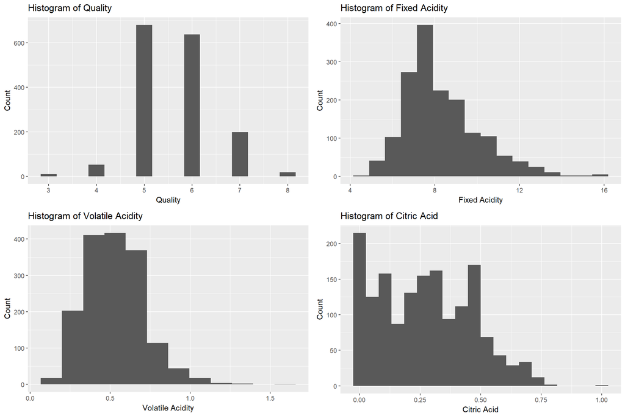

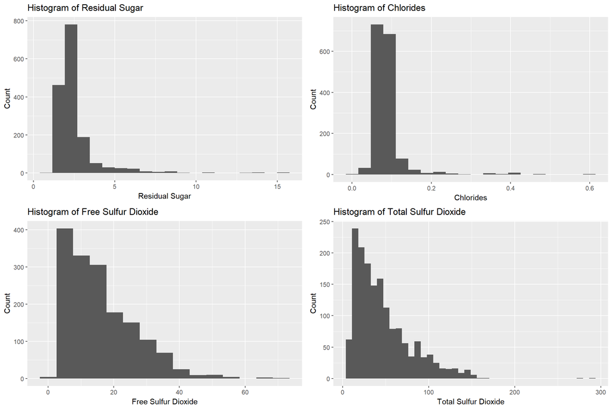

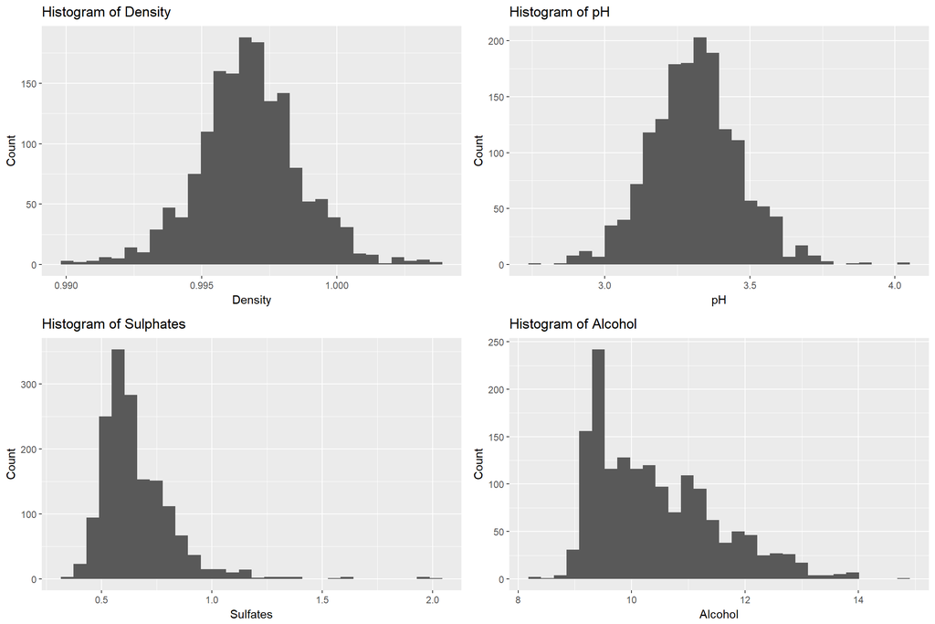

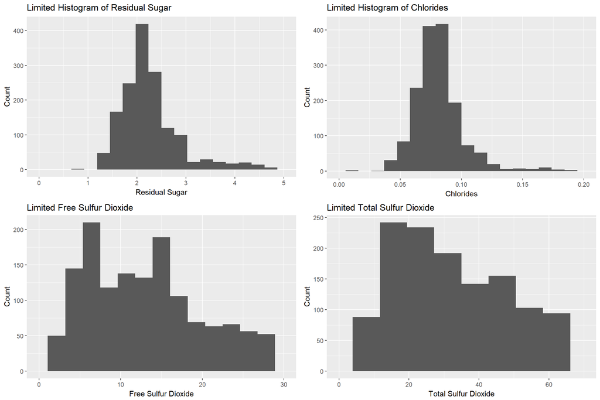

If we alter the bin size and the x values that are included we can see more normalized graph. This gets rid of the smaller, outlier values so that we can see the main bulk of records.

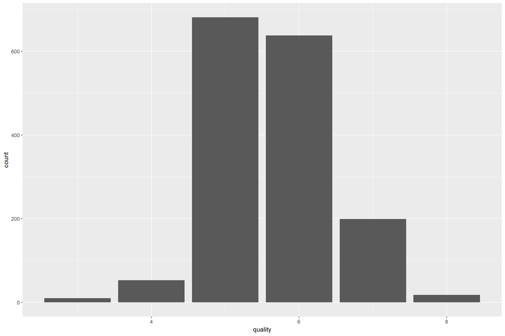

With this graph, we can see the majority of the wine falls between quality 5 and 6. This lets gives us the indicator that anything above a 6 in quality is better than average wine. We want to look for trends in what kinds of wine have this better than average rating.

# Univariate Analysis

# Bivariate Plots Section

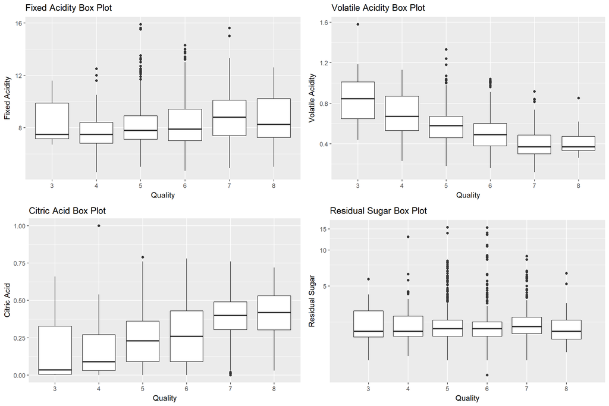

```
##
##  Pearson's product-moment correlation
##
## data:  wineInfo$quality and wineInfo$fixed.acidity
## t = 4.996, df = 1597, p-value = 6.496e-07
## alternative hypothesis: true correlation is not equal to 0
## 95 percent confidence interval:
##  0.07548957 0.17202667
## sample estimates:
##       cor
## 0.1240516
```

```
##
##  Pearson's product-moment correlation
##
## data:  wineInfo$quality and wineInfo$volatile.acidity
## t = -16.954, df = 1597, p-value < 2.2e-16
## alternative hypothesis: true correlation is not equal to 0
## 95 percent confidence interval:
##  -0.4313210 -0.3482032
## sample estimates:
##        cor
## -0.3905578
```

```
##
##  Pearson's product-moment correlation
##
## data:  wineInfo$quality and wineInfo$citric.acid
## t = 9.2875, df = 1597, p-value < 2.2e-16
## alternative hypothesis: true correlation is not equal to 0
## 95 percent confidence interval:
##  0.1793415 0.2723711
## sample estimates:
##       cor
## 0.2263725
```

```
##
##  Pearson's product-moment correlation
##
## data:  wineInfo$quality and wineInfo$residual.sugar
## t = 0.5488, df = 1597, p-value = 0.5832
## alternative hypothesis: true correlation is not equal to 0
## 95 percent confidence interval:
##  -0.03531327  0.06271056
## sample estimates:
##        cor
## 0.01373164
```

The first box plot compares Fixed Acidity vs Quality. I wanted to see if there was a trend between levels of fixed acidity and quality. From looking at these plots it doesn’t seem that there is much of a trend.

The second box plot compares Volatile Acidity vs Quality. There appears to be a trend that less volatile acidity tends to have better quality.

The third box plot compares Citric Acid vs Quality. This plot trends the opposite way of volatile acidity in that more citric acid tended to get better ratings.

The fourth plot compares residual sugar with quality. It appears that there is not much trend between residual sugar and quality.

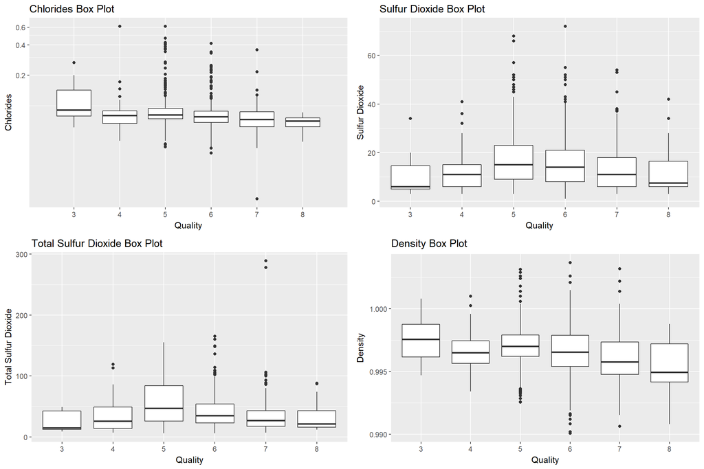

```
##
##  Pearson's product-moment correlation
##
## data:  wineInfo$quality and wineInfo$chlorides
## t = -5.1948, df = 1597, p-value = 2.313e-07
## alternative hypothesis: true correlation is not equal to 0
## 95 percent confidence interval:
##  -0.17681041 -0.08039344
## sample estimates:
##        cor
## -0.1289066
```

```
##
##  Pearson's product-moment correlation
##
## data:  wineInfo$quality and wineInfo$free.sulfur.dioxide
## t = -2.0269, df = 1597, p-value = 0.04283
## alternative hypothesis: true correlation is not equal to 0
## 95 percent confidence interval:
##  -0.099430290 -0.001638987
## sample estimates:
##         cor
## -0.05065606
```

```
##
##  Pearson's product-moment correlation
##
## data:  wineInfo$quality and wineInfo$total.sulfur.dioxide
## t = -7.5271, df = 1597, p-value = 8.622e-14
## alternative hypothesis: true correlation is not equal to 0
## 95 percent confidence interval:
##  -0.2320162 -0.1373252
## sample estimates:
##        cor
## -0.1851003
```

```
##
##  Pearson's product-moment correlation
##
## data:  wineInfo$quality and wineInfo$density
## t = -7.0997, df = 1597, p-value = 1.875e-12
## alternative hypothesis: true correlation is not equal to 0
## 95 percent confidence interval:
##  -0.2220365 -0.1269870
## sample estimates:
##        cor
## -0.1749192
```

The first box plot here compares chlorides to quality. Here it seems that less chlorides might translate to better quality. This is not 100% clear so more investigation will be needed.

The second box compares sulfur dioxide to quality. There doesn’t appear to much correlation here.

The third box plot is total sulfur dioxide vs quality. There also doesn’t appear to be much correlation here.

The fourth box plot is density vs quality. It seems there might be a correlation to less dense wine being higher quality but like chlorides there needs to be more investigation.

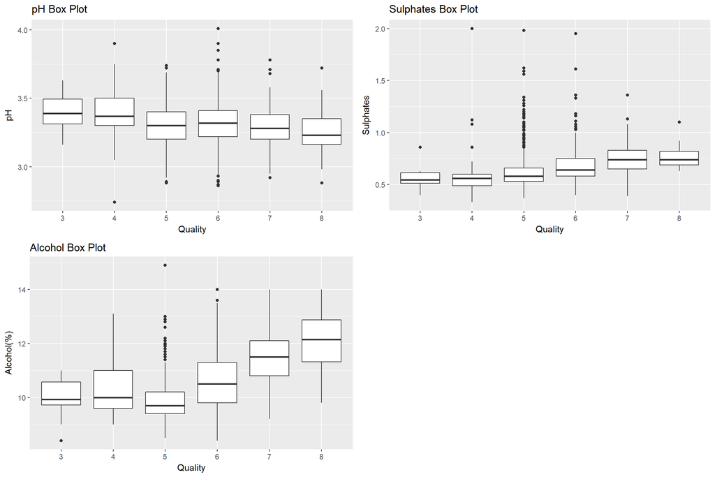

```
##
##  Pearson's product-moment correlation
##
## data:  wineInfo$quality and wineInfo$sulphates
## t = 10.38, df = 1597, p-value < 2.2e-16
## alternative hypothesis: true correlation is not equal to 0
## 95 percent confidence interval:
##  0.2049011 0.2967610
## sample estimates:
##       cor
## 0.2513971
```

```
##
##  Pearson's product-moment correlation
##
## data:  wineInfo$quality and wineInfo$pH
## t = -2.3109, df = 1597, p-value = 0.02096
## alternative hypothesis: true correlation is not equal to 0
## 95 percent confidence interval:
##  -0.106451268 -0.008734972
## sample estimates:
##         cor
## -0.05773139
```

```
##
##  Pearson's product-moment correlation
##
## data:  wineInfo$quality and wineInfo$alcohol
## t = 21.639, df = 1597, p-value < 2.2e-16
## alternative hypothesis: true correlation is not equal to 0
## 95 percent confidence interval:
##  0.4373540 0.5132081
## sample estimates:
##       cor
## 0.4761663
```

This first plot is pH vs quality. There doesn’t appear to be much correlation.

The second plot is sulphates vs quality. It appears that higher sulphates translate to higher quality wine.

The last plot is alcohol vs quality. There is a strong trend between higher alcohol and higher quality.

After conducting Pearson’s correlation on all of the data it is clear that alcohol, fixed acidity, citric acid, and sulphates all have positive correlations with quality. This is in contrast to density, total sulfur dioxide, free sulfur, chlorides, total sulfur,and volatile acidity which were negative.

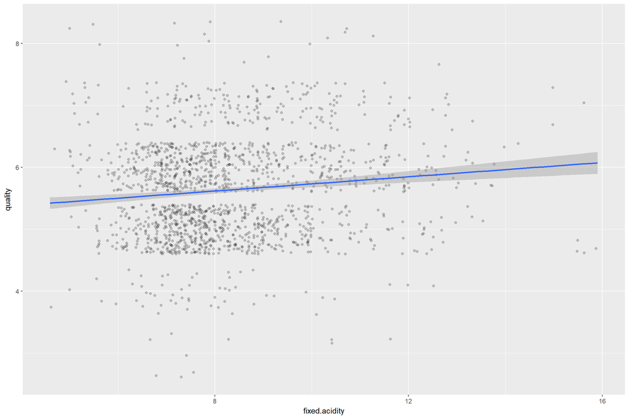

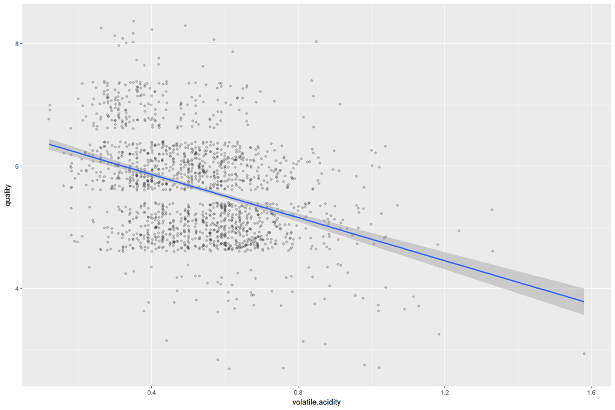

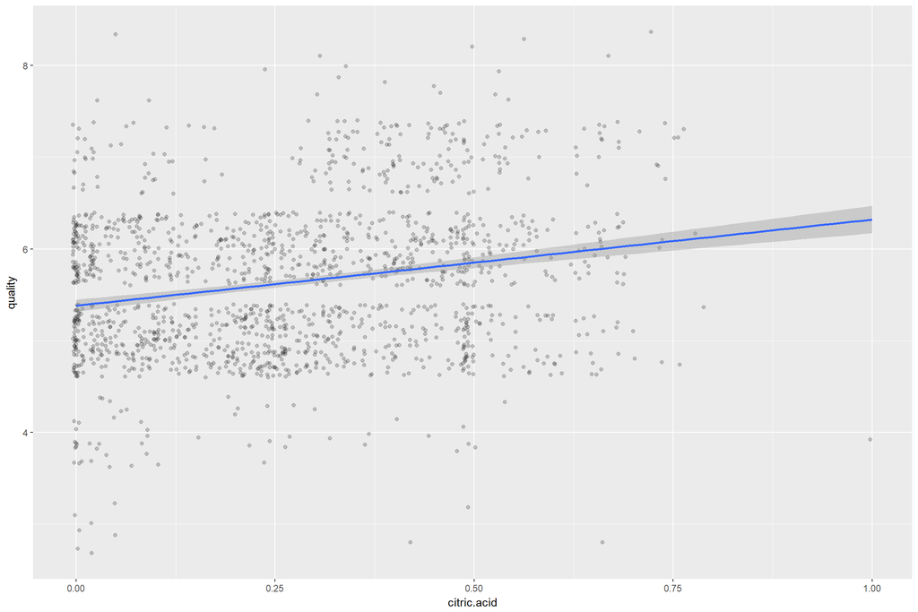

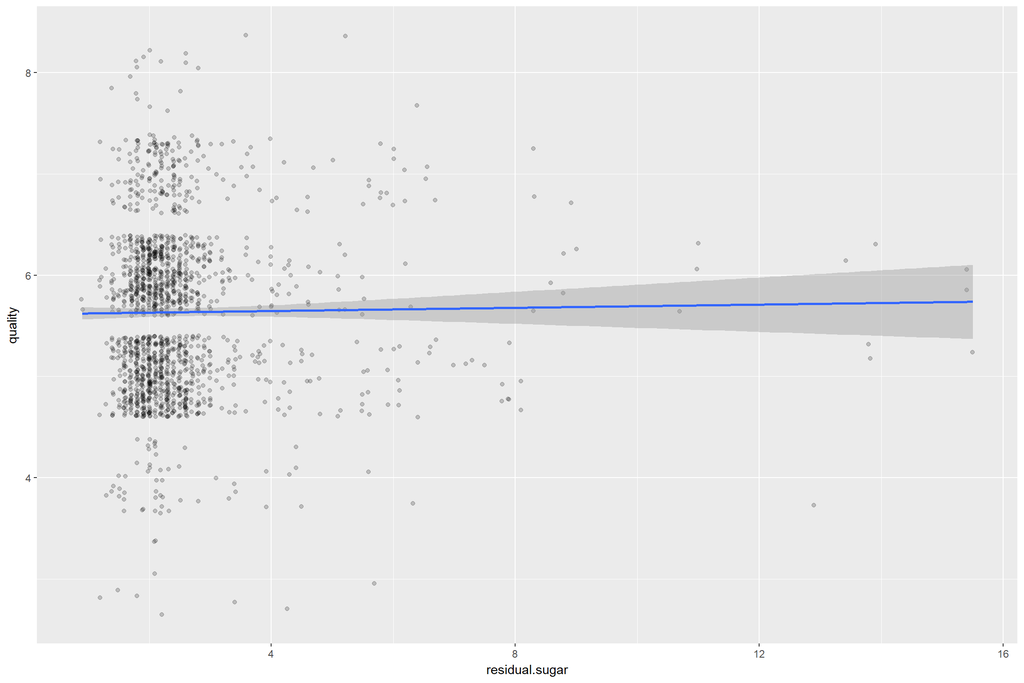

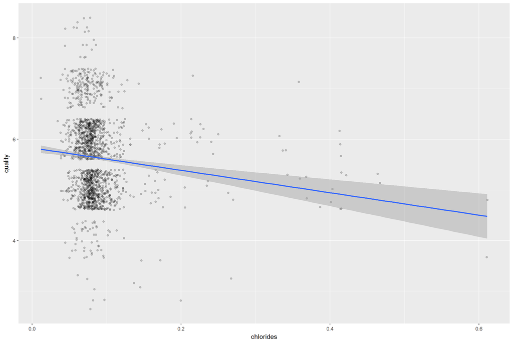

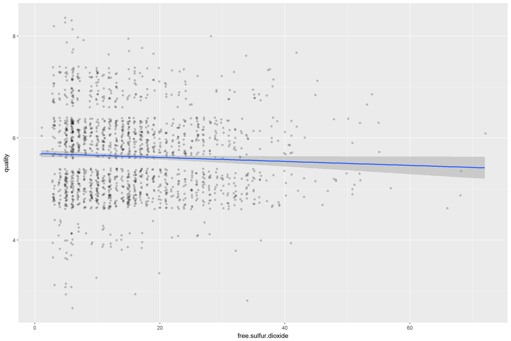

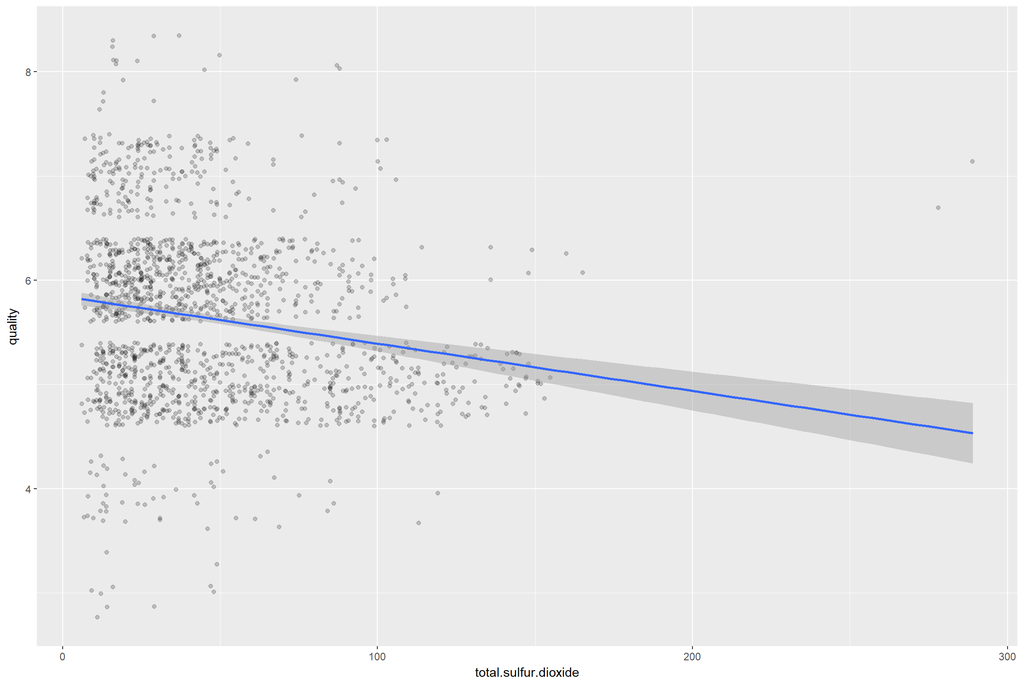

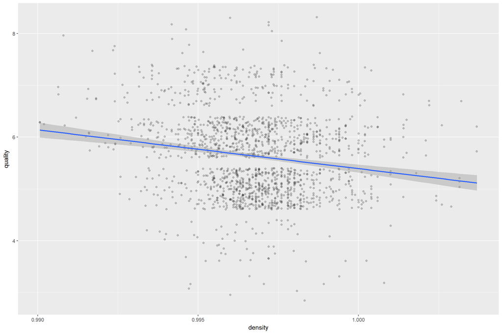

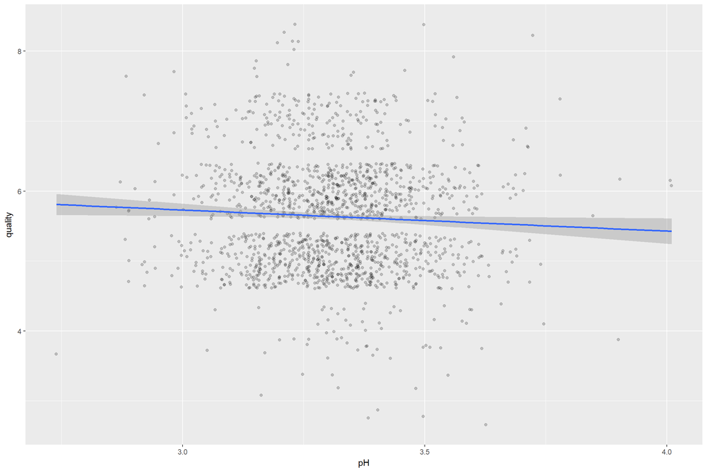

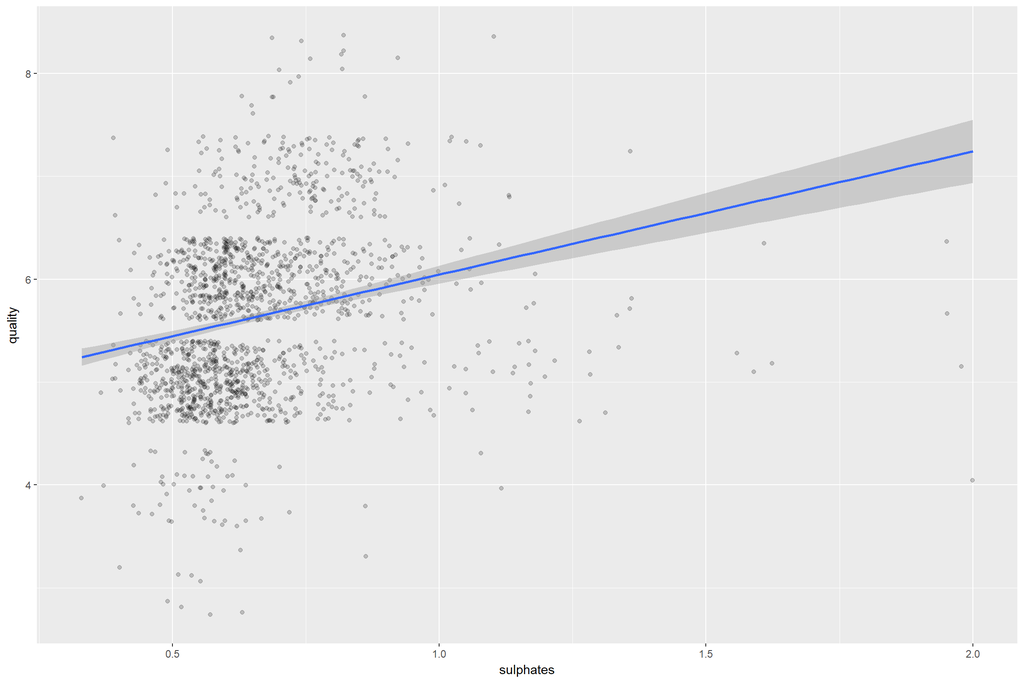

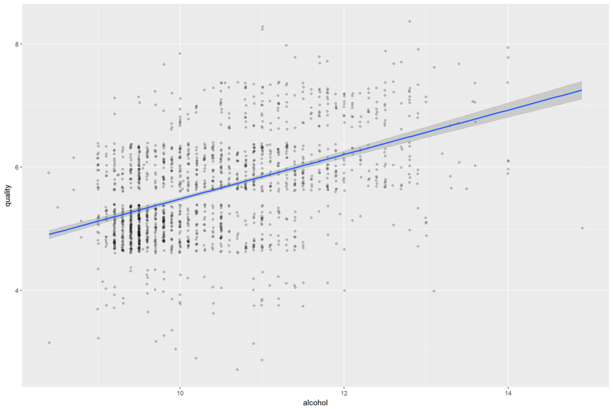

These graphs show the linear regression line when the characteristics are compared to quality. The lines that had the largest slopes were the ones that also happened to have the largest positve correlations.

# Bivariate Analysis

# Multivariate Plots Section

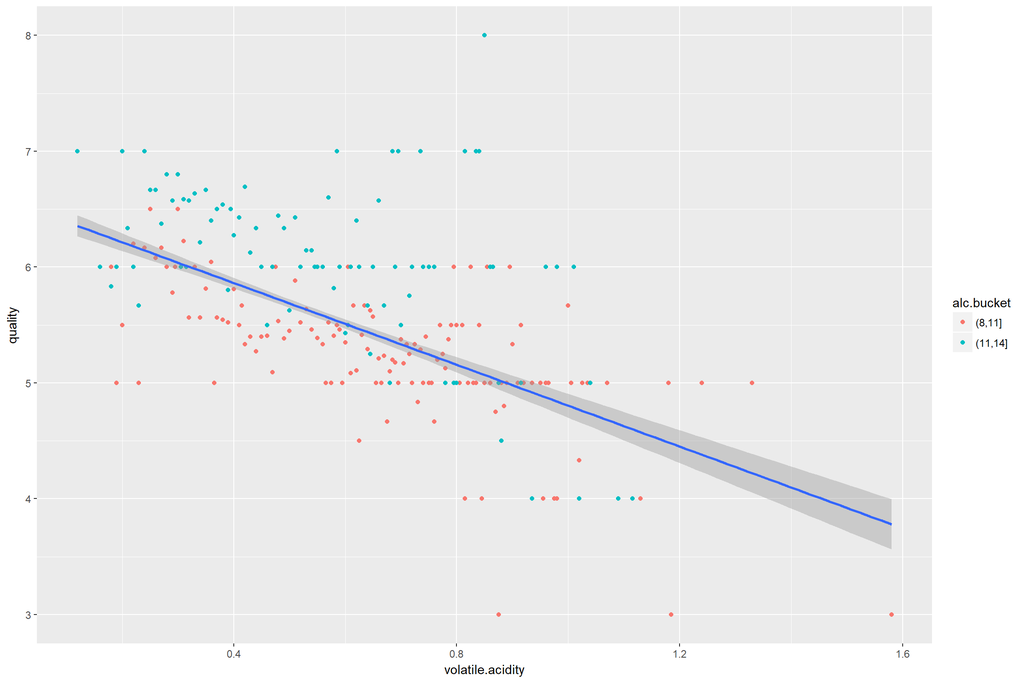

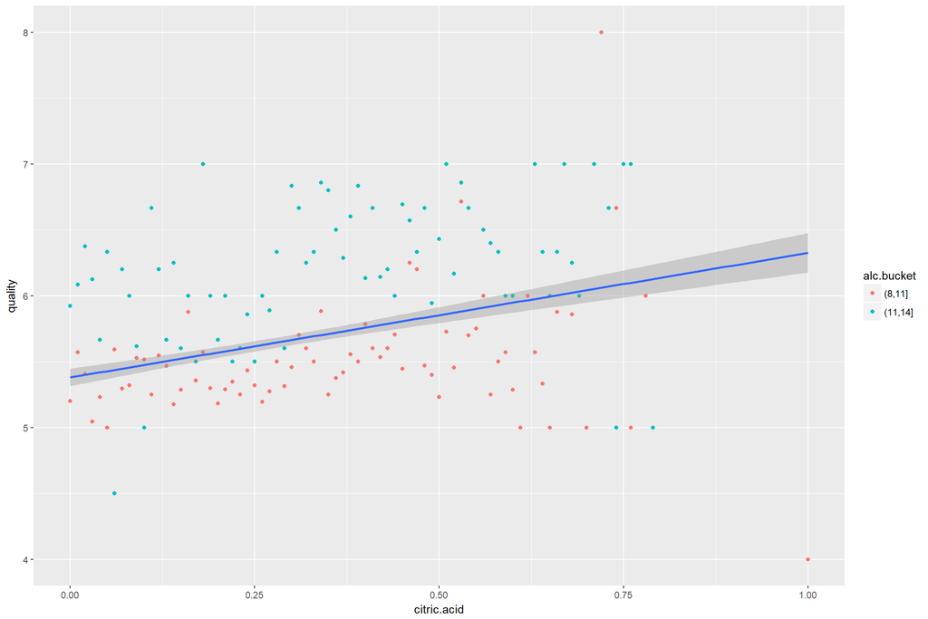

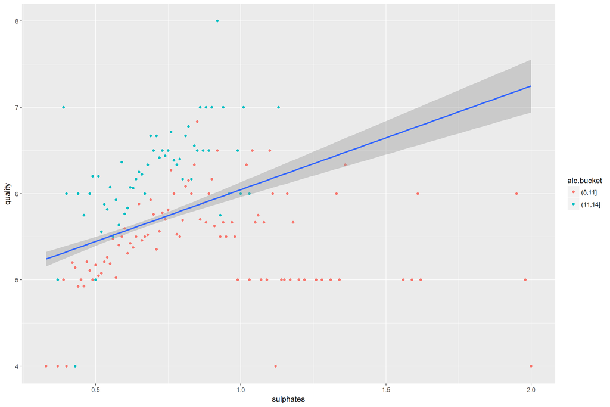

Because alcohol had the strongest correlation, I took my earlier graphs and compared them again with alcohol as a 2nd variable. The dots are shaded different based on the different levels of alcohol in each. It seems that this graph definitely indicates that higher alcohol is definitely correlated with higher quality.

# Multivariate Analysis

It is clear from the multivariate analysis that alcohol was the most important factor in determining quality. The other three characteristics all seemed to have a smaller porportional effect on the quality as well.

# Final Plots and Summary

### Plot One

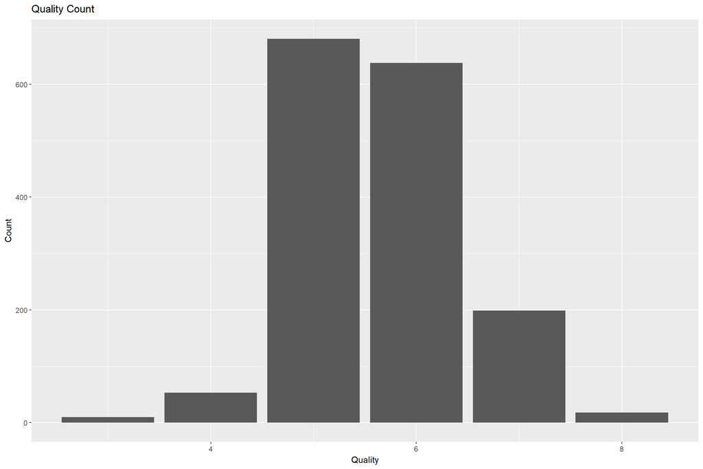

### Description One

I used this graph because it gave me a good initial indication as to what would be considered good wine vs average wine. I noticed that most of the wine feel into a rating of 5,or 6 which meant that anything about 6 could be considered high quality. This bench mark was used for much of my analysis.

### Plot Two

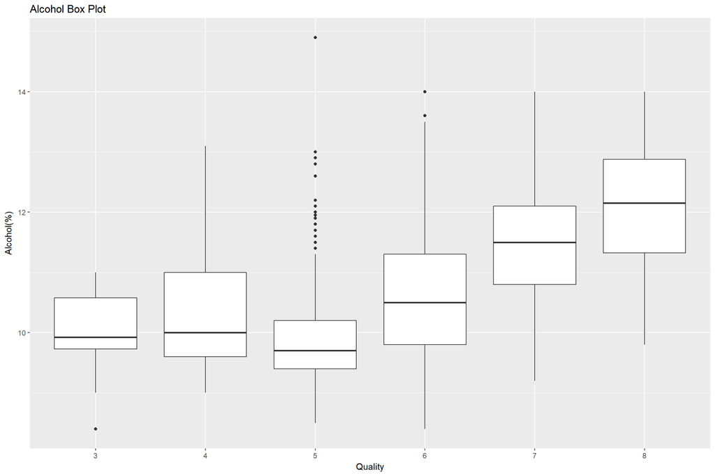

### Description Two

I chose to include the box plot of alcohol and quality because I felt that it was the first piece of information that caught my eye when trying to find characteristics of high quality wine. The box plots for the higher quality wines tended to fall higher in alcohol content.

### Plot Three

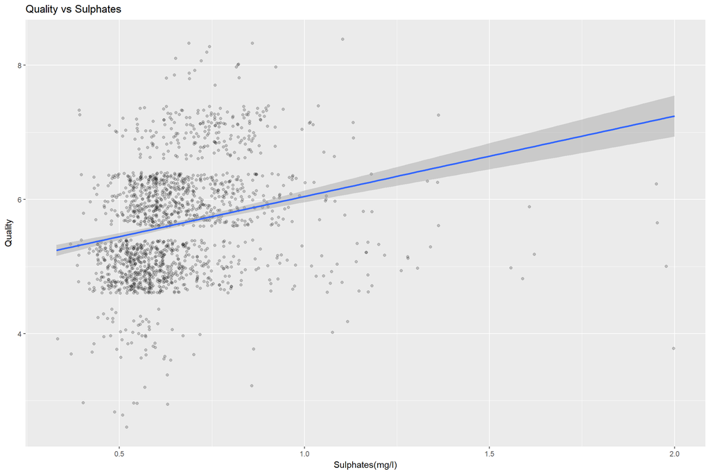

# Reflection

My biggest obstacle was removing outliers from the data so that I could normalize it. Residual sugar, chlorides, free sulfur dioxide, and total sulfur dioxide were the characteristics that needed to have outliers removed. Another problem I encountered was being able to create box plots with an x value that was continous. I was able to fix this using the group function.

Going forward I think there needs to be an investigation to whether alcohol is causing a random correlation or an actual causation to an increased quality level. I think BAC of the person creating the quality rating should be accounted for if they are making a judgement based on drinking the wine.